# Group 4 Assignment 3

## (Q2) Decision Tree

**Note on `tidymodels`: the `tidymodels` framework is a wrapper around the various packages that one can use for the same modeling methods. The specific functions of this package may be new to the reader, however we hope that the intent of the following code is easy to follow even for the reader unfamiliar with `tidymodels`. We do not use the `tidymodels` framework for all questions in this homework.

```r
Datatrain <- read_rds('data/loans_dv_train.Rds') %>%
  mutate(Loan_Status = ifelse(Loan_Status.Y, "Y", "N")) %>%
  select(-Loan_Status.N, -Loan_Status.Y)

Datatest <- read_rds('data/loans_dv_test.Rds') %>%
  mutate(Loan_Status = ifelse(Loan_Status.Y, "Y", "N")) %>%
  select(-Loan_Status.N, -Loan_Status.Y)

datacv <- vfold_cv(Datatrain, v = 10, strata = Loan_Status)

tree_engine <-
    decision_tree(mode = "classification") %>%
    parsnip::set_engine(engine = "rpart")

dt_wf <-
    workflow() %>%
    workflows::add_model(tree_engine)
```

### Candidate models

We ran several iterations of models to determine the best data preparation steps above. We have not included each intermediate model. If the reader is interested in reading that code, the authors will make it available.

#### Baseline model

Kappa is a metric used to measure accuracy that is normalized based on the class distribution and will be used to compare model performance. For Kappa, values of 0-0.20 as slight, 0.21-0.40 as fair, 0.41-0.60 as moderate, 0.61-0.80 as substantial, and 0.81-1 as almost perfect.

```r
All_metrics <- data.frame()


# Baseline Model = #1
dt_recipe1 <-
  recipe(Loan_Status ~ ., data = Datatrain)

dt_recipe1 %>% prep()
```

```
## Data Recipe
##
## Inputs:
##
##       role #variables
##    outcome          1
##  predictor         28
##
## Training data contained 461 data points and no missing data.
```

```r
dt_wf1<-
 dt_wf %>%
  add_recipe(dt_recipe1)

wf1_results <- dt_wf1 %>%
  fit_resamples(
    resamples= datacv,
    metrics = metric_set(
      roc_auc, accuracy, sensitivity, specificity, kap),
    control = control_resamples(save_pred = TRUE))

wf1_results %>% collect_metrics(summarize = TRUE)
```

```
## # A tibble: 5 x 6
##   .metric  .estimator  mean     n std_err .config
##   <chr>    <chr>      <dbl> <int>   <dbl> <chr>
## 1 accuracy binary     0.826    10 0.0114  Preprocessor1_Model1
## 2 kap      binary     0.546    10 0.0351  Preprocessor1_Model1
## 3 roc_auc  binary     0.753    10 0.0199  Preprocessor1_Model1
## 4 sens     binary     0.534    10 0.0384  Preprocessor1_Model1
## 5 spec     binary     0.959    10 0.00934 Preprocessor1_Model1
```

```r
wf_res_function <-
  function(wf_results, modelname) {
    # this function returns
    # ROC_AUC, accuracy, and KAPPA of a cross validated model result

    All_metrics %>% bind_rows(
      collect_metrics(wf_results, summarize = T) %>%
      mutate(model = modelname))
  }

All_metrics <- wf_res_function(wf1_results, "Baseline")
```

#### Down-sampling test model

This model starts with the baseline and adds down-sampling to balance our response variable. The down-sampling was tested at a few ratios from 1:1 to 1:2. the optimal ratio is presented below at 1.8 with 35% `N` and 65% `Y` – a 4% adjustment in the class balance.

```r
# Down-sampling = #3
set.seed(0)

dt_recipe3 <-
  dt_recipe1 %>%
  themis::step_downsample(Loan_Status, skip = TRUE, under_ratio = 1.8)

table(juice(prep(dt_recipe3, training = Datatrain))$Loan_Status)
```

```
##
##   N   Y
## 144 259
```

```r
dt_wf3<-
 dt_wf %>%
  add_recipe(dt_recipe3)

dt_recipe3 %>% prep()
```

```
## Data Recipe
##
## Inputs:
##
##       role #variables
##    outcome          1
##  predictor         28
##
## Training data contained 461 data points and no missing data.
##
## Operations:
##
## Down-sampling based on Loan_Status [trained]
```

```r
wf3_results <- dt_wf3 %>%
  fit_resamples(
    resamples = datacv,
    metrics = metric_set(
      roc_auc, accuracy, sensitivity, specificity, kap),
    control = control_resamples(save_pred = TRUE))

wf3_results %>% collect_metrics(summarize = TRUE)
```

```
## # A tibble: 5 x 6
##   .metric  .estimator  mean     n std_err .config
##   <chr>    <chr>      <dbl> <int>   <dbl> <chr>
## 1 accuracy binary     0.818    10  0.0110 Preprocessor1_Model1
## 2 kap      binary     0.528    10  0.0337 Preprocessor1_Model1
## 3 roc_auc  binary     0.754    10  0.0232 Preprocessor1_Model1
## 4 sens     binary     0.535    10  0.0421 Preprocessor1_Model1
## 5 spec     binary     0.946    10  0.0124 Preprocessor1_Model1
```

```r
All_metrics <-
  wf_res_function(wf3_results, "Downsample")
```

### Discretization Testing model

```r
# Binned = #6
dt_recipe6 <-
  dt_recipe3 %>%
  step_discretize(Total_Income, num_breaks = 8)

dt_recipe6 %>% prep
```

```
## Data Recipe
##
## Inputs:
##
##       role #variables
##    outcome          1
##  predictor         28
##
## Training data contained 461 data points and no missing data.
##
## Operations:
##
## Down-sampling based on Loan_Status [trained]
## Dummy variables from Total_Income [trained]
```

```r
dt_wf6 <-
 dt_wf %>%
  add_recipe(dt_recipe6)

wf6_results <- dt_wf6 %>%
  fit_resamples(
    resamples = datacv,
    metrics = metric_set(
      roc_auc, accuracy, sensitivity, specificity, kap),
    control = control_resamples(save_pred = TRUE))

wf6_results %>% collect_metrics(summarize = TRUE)
```

```
## # A tibble: 5 x 6
##   .metric  .estimator  mean     n std_err .config
##   <chr>    <chr>      <dbl> <int>   <dbl> <chr>
## 1 accuracy binary     0.815    10 0.00961 Preprocessor1_Model1
## 2 kap      binary     0.521    10 0.0303  Preprocessor1_Model1
## 3 roc_auc  binary     0.741    10 0.0220  Preprocessor1_Model1
## 4 sens     binary     0.528    10 0.0399  Preprocessor1_Model1
## 5 spec     binary     0.946    10 0.0134  Preprocessor1_Model1
```

```r
All_metrics <- wf_res_function(wf6_results, "Binning")
```

```r
All_metrics %>%
  filter(.metric == "kap") %>%
  kable() %>%
  kable_styling(
    full_width = FALSE, position = "center", bootstrap_options = c("hover"))
```

| .metric | .estimator | mean | n | std_err | .config | model |
| --- | --- | --- | --- | --- | --- | --- |
| kap | binary | 0.5462085 | 10 | 0.0350986 | Preprocessor1_Model1 | Baseline |
| kap | binary | 0.5275444 | 10 | 0.0337066 | Preprocessor1_Model1 | Downsample |
| kap | binary | 0.5214442 | 10 | 0.0302933 | Preprocessor1_Model1 | Binning |

### Model Tuning

- `cost_complexity`: represents the amount of information gain required for a tree to continue splitting along a node
- `tree_depth`: represents the maximum amount of branches a tree may extend before terminating
- `min_n`: represents the minimum number of datapoints required at a node for a split to be made

In order to test various values, a grid of these features are set up with various combinations of options as shown below.

```r
tree_grid <- grid_regular(
  cost_complexity(), tree_depth(), min_n(), levels = 4)
tree_grid %>%
  kable %>%
  kable_styling(
      full_width = F, position="center", bootstrap_options = c("hover")) %>%
  scroll_box(height = "200px")
```

| cost_complexity | tree_depth | min_n |
| --- | --- | --- |
| 0e+00 | 1 | 2 |
| 1e-07 | 1 | 2 |
| 1e-04 | 1 | 2 |
| 1e-01 | 1 | 2 |
| 0e+00 | 5 | 2 |
| 1e-07 | 5 | 2 |
| 1e-04 | 5 | 2 |
| 1e-01 | 5 | 2 |
| 0e+00 | 10 | 2 |
| 1e-07 | 10 | 2 |
| 1e-04 | 10 | 2 |
| 1e-01 | 10 | 2 |
| 0e+00 | 15 | 2 |
| 1e-07 | 15 | 2 |
| 1e-04 | 15 | 2 |
| 1e-01 | 15 | 2 |
| 0e+00 | 1 | 14 |
| 1e-07 | 1 | 14 |
| 1e-04 | 1 | 14 |
| 1e-01 | 1 | 14 |
| 0e+00 | 5 | 14 |
| 1e-07 | 5 | 14 |
| 1e-04 | 5 | 14 |
| 1e-01 | 5 | 14 |
| 0e+00 | 10 | 14 |
| 1e-07 | 10 | 14 |
| 1e-04 | 10 | 14 |
| 1e-01 | 10 | 14 |
| 0e+00 | 15 | 14 |
| 1e-07 | 15 | 14 |
| 1e-04 | 15 | 14 |
| 1e-01 | 15 | 14 |
| 0e+00 | 1 | 27 |
| 1e-07 | 1 | 27 |
| 1e-04 | 1 | 27 |
| 1e-01 | 1 | 27 |
| 0e+00 | 5 | 27 |
| 1e-07 | 5 | 27 |
| 1e-04 | 5 | 27 |
| 1e-01 | 5 | 27 |
| 0e+00 | 10 | 27 |
| 1e-07 | 10 | 27 |
| 1e-04 | 10 | 27 |
| 1e-01 | 10 | 27 |
| 0e+00 | 15 | 27 |
| 1e-07 | 15 | 27 |
| 1e-04 | 15 | 27 |
| 1e-01 | 15 | 27 |
| 0e+00 | 1 | 40 |
| 1e-07 | 1 | 40 |
| 1e-04 | 1 | 40 |
| 1e-01 | 1 | 40 |
| 0e+00 | 5 | 40 |
| 1e-07 | 5 | 40 |
| 1e-04 | 5 | 40 |
| 1e-01 | 5 | 40 |
| 0e+00 | 10 | 40 |
| 1e-07 | 10 | 40 |
| 1e-04 | 10 | 40 |
| 1e-01 | 10 | 40 |
| 0e+00 | 15 | 40 |
| 1e-07 | 15 | 40 |
| 1e-04 | 15 | 40 |
| 1e-01 | 15 | 40 |

All of these values are testing on the 10-fold cross-validation set where the result of every combination along each 10 splits of the data are averaged. The results of this tuning exercise is plotted below. KAP is the metric used to select the best tree, where the minimum cost function, a tree depth of 5 and a minimal node size of 40 is shown to be optimal.

```r
doParallel::registerDoParallel()

tree_engine <-
  decision_tree(
    mode = "classification",
    cost_complexity = tune(), # min improvement needed at each node
    tree_depth = tune(), # max depth of the tree allowed
    min_n(tune()) # min number of datapoints required
  ) %>%
  set_engine(engine = "rpart")

# Loading cached object for document generation
#
# set.seed(3)
# tree_rs <- tune_grid(
#  object =  tree_engine,
#  preprocessor = dt_recipe6,
#  resamples = datacv,
#  grid = tree_grid,
#  metrics = metric_set(accuracy, kap)
# )
# readr::write_rds(tree_rs, 'output/q2_tree_rs.Rds')
#
tree_rs <- readr::read_rds('output/q2_tree_rs.Rds')

collect_metrics(tree_rs) %>%
  kable() %>%
  kable_styling(
    full_width = F, position="center", bootstrap_options = c("hover")) %>%
  scroll_box(height = "200px")
```

| cost_complexity | tree_depth | min_n | .metric | .estimator | mean | n | std_err | .config |
| --- | --- | --- | --- | --- | --- | --- | --- | --- |
| 0e+00 | 1 | 2 | accuracy | binary | 0.8177120 | 10 | 0.0155097 | Preprocessor1_Model01 |
| 0e+00 | 1 | 2 | kap | binary | 0.4992879 | 10 | 0.0484900 | Preprocessor1_Model01 |
| 1e-07 | 1 | 2 | accuracy | binary | 0.8177120 | 10 | 0.0155097 | Preprocessor1_Model02 |
| 1e-07 | 1 | 2 | kap | binary | 0.4992879 | 10 | 0.0484900 | Preprocessor1_Model02 |
| 1e-04 | 1 | 2 | accuracy | binary | 0.8177120 | 10 | 0.0155097 | Preprocessor1_Model03 |
| 1e-04 | 1 | 2 | kap | binary | 0.4992879 | 10 | 0.0484900 | Preprocessor1_Model03 |
| 1e-01 | 1 | 2 | accuracy | binary | 0.8177120 | 10 | 0.0155097 | Preprocessor1_Model04 |
| 1e-01 | 1 | 2 | kap | binary | 0.4992879 | 10 | 0.0484900 | Preprocessor1_Model04 |
| 0e+00 | 5 | 2 | accuracy | binary | 0.7789434 | 10 | 0.0173302 | Preprocessor1_Model05 |
| 0e+00 | 5 | 2 | kap | binary | 0.4281378 | 10 | 0.0437256 | Preprocessor1_Model05 |
| 1e-07 | 5 | 2 | accuracy | binary | 0.7789434 | 10 | 0.0173302 | Preprocessor1_Model06 |
| 1e-07 | 5 | 2 | kap | binary | 0.4281378 | 10 | 0.0437256 | Preprocessor1_Model06 |
| 1e-04 | 5 | 2 | accuracy | binary | 0.7789434 | 10 | 0.0173302 | Preprocessor1_Model07 |
| 1e-04 | 5 | 2 | kap | binary | 0.4281378 | 10 | 0.0437256 | Preprocessor1_Model07 |
| 1e-01 | 5 | 2 | accuracy | binary | 0.8177120 | 10 | 0.0155097 | Preprocessor1_Model08 |
| 1e-01 | 5 | 2 | kap | binary | 0.4992879 | 10 | 0.0484900 | Preprocessor1_Model08 |
| 0e+00 | 10 | 2 | accuracy | binary | 0.7396618 | 10 | 0.0129704 | Preprocessor1_Model09 |
| 0e+00 | 10 | 2 | kap | binary | 0.3670301 | 10 | 0.0399304 | Preprocessor1_Model09 |
| 1e-07 | 10 | 2 | accuracy | binary | 0.7396618 | 10 | 0.0129704 | Preprocessor1_Model10 |
| 1e-07 | 10 | 2 | kap | binary | 0.3670301 | 10 | 0.0399304 | Preprocessor1_Model10 |
| 1e-04 | 10 | 2 | accuracy | binary | 0.7396618 | 10 | 0.0129704 | Preprocessor1_Model11 |
| 1e-04 | 10 | 2 | kap | binary | 0.3670301 | 10 | 0.0399304 | Preprocessor1_Model11 |
| 1e-01 | 10 | 2 | accuracy | binary | 0.8177120 | 10 | 0.0155097 | Preprocessor1_Model12 |
| 1e-01 | 10 | 2 | kap | binary | 0.4992879 | 10 | 0.0484900 | Preprocessor1_Model12 |
| 0e+00 | 15 | 2 | accuracy | binary | 0.7025501 | 10 | 0.0207084 | Preprocessor1_Model13 |
| 0e+00 | 15 | 2 | kap | binary | 0.3176340 | 10 | 0.0538731 | Preprocessor1_Model13 |
| 1e-07 | 15 | 2 | accuracy | binary | 0.7025501 | 10 | 0.0207084 | Preprocessor1_Model14 |
| 1e-07 | 15 | 2 | kap | binary | 0.3176340 | 10 | 0.0538731 | Preprocessor1_Model14 |
| 1e-04 | 15 | 2 | accuracy | binary | 0.7025501 | 10 | 0.0207084 | Preprocessor1_Model15 |
| 1e-04 | 15 | 2 | kap | binary | 0.3176340 | 10 | 0.0538731 | Preprocessor1_Model15 |

[output cut: 98 more lines]

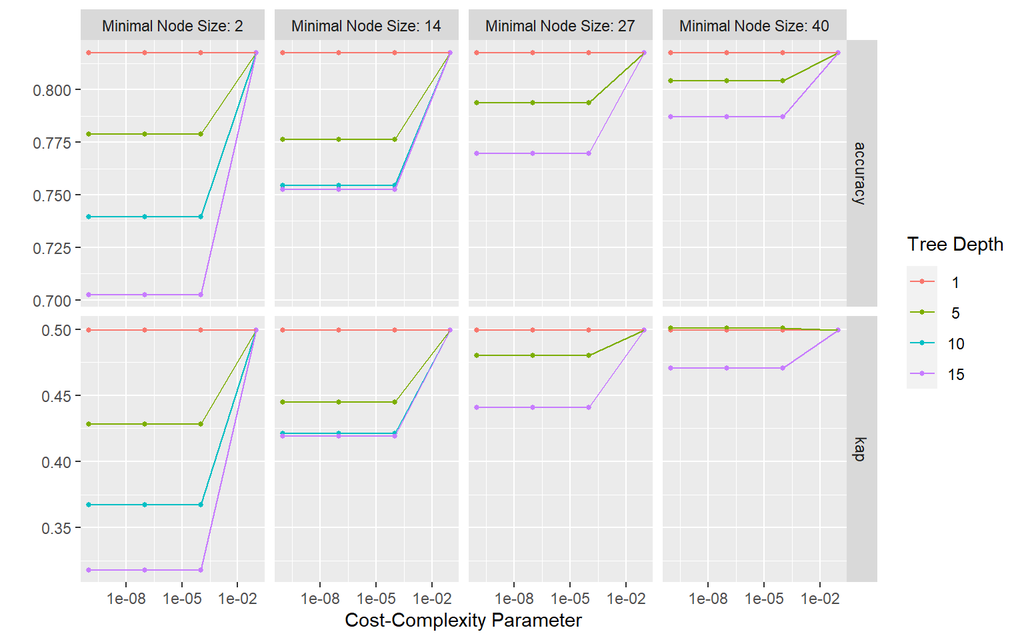

```r
# tree_rs %>% autoplot() + theme_light(base_family = "IBMPlexSans")
tree_rs %>% autoplot()
```

### Finalize decision

We can finalize our decision and create our decision tree based on the following specification:

```r
show_best(tree_rs, "kap")
```

```
## # A tibble: 5 x 9
##   cost_complexity tree_depth min_n .metric .estimator  mean     n std_err
##             <dbl>      <int> <int> <chr>   <chr>      <dbl> <int>   <dbl>
## 1    0.0000000001          5    40 kap     binary     0.501    10  0.0388
## 2    0.0000001             5    40 kap     binary     0.501    10  0.0388
## 3    0.0001                5    40 kap     binary     0.501    10  0.0388
## 4    0.0000000001          1     2 kap     binary     0.499    10  0.0485
## 5    0.0000001             1     2 kap     binary     0.499    10  0.0485
## # ... with 1 more variable: .config <chr>
```

```r
final_tree <- finalize_model(tree_engine, select_best(tree_rs, "kap"))

final_tree
```

```
## Decision Tree Model Specification (classification)
##
## Main Arguments:
##   cost_complexity = 1e-10
##   tree_depth = 5
##   min_n = 40
##
## Computational engine: rpart
```

A visual of our fitted model tree to the training dataset is shown below. The first value in the tree nodes indicate Y/N on whether there loan default would be predicted at that node, the second values shows the probability associated with `N` on the left and `Y` on the right. the third row in the node shows the percentage of the data contained in each node. The top most node depicts the most descriptive feature of our classification model, while following nodes depict secondary descriptive features. Due to the tree specifications (40 data points needed minimum at each node) only two main features are used to predict `LoanStatus` which are `Credit_History` and `IncomeLoanRatio`.

[figure not shown]

```r
final_wf <-
  workflow() %>%
  add_model(final_tree) %>%
  add_recipe(dt_recipe6)

wf_final_results <- final_wf %>%
  fit_resamples(
    resamples = datacv,
    metrics = metric_set(
      roc_auc, accuracy, sensitivity, specificity, kap),
    control = control_resamples(save_pred = TRUE))


All_metrics <- wf_res_function(wf_final_results, "wf_final")

dtmodel <- final_wf %>% fit(data = Datatrain)

rattle::fancyRpartPlot(dtmodel$fit$fit$fit,palettes="RdPu")
```

### Variable Importance Plot

Additional information about the variable importance was extracted from the model and shown in the variable importance plot below. where `Credit_History` has an overwhelming weight of importance, followed by our engineered feature `IncomeLoanRatio`.

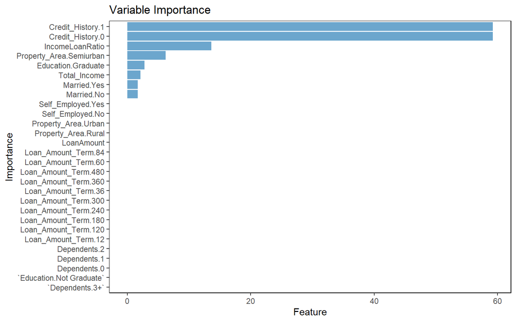

```r
mod <- dtmodel$fit$fit$fit

# For plotting tree
caret::varImp(mod) %>%
  mutate(Feature = rownames(.)) %>%
  ggplot(
    mapping = aes(x = fct_reorder(Feature, Overall), y = Overall)) +
  geom_col(fill ="skyblue3") +
  coord_flip() +
  defaulttheme +
  labs(
    x = "Importance",
    y = "Feature",
    title = "Variable Importance")
```

```r
training_predictions <- predict(
  dtmodel,
  new_data = Datatrain,
  type = "class") %>%
  bind_cols(Datatrain$Loan_Status) %>%
  rename("Loan_Status" = "...2") %>%
  mutate(
    set = "Training",
    Loan_Status = factor(Loan_Status))
```

### Confusion Matrix, Accuracy

```r
training_predictions %>% conf_mat(truth = Loan_Status, estimate=.pred_class)
```

```
##           Truth
## Prediction   N   Y
##          N  75  10
##          Y  69 307
```

```r
metrics(
  training_predictions,
  truth = Loan_Status,
  estimate = .pred_class)
```

```
## # A tibble: 2 x 3
##   .metric  .estimator .estimate
##   <chr>    <chr>          <dbl>
## 1 accuracy binary         0.829
## 2 kap      binary         0.551
```

```r
testing_predictions <- predict(
  dtmodel,
  new_data = Datatest,
  type = "class") %>%
  bind_cols(Datatest$Loan_Status) %>%
  rename("Loan_Status"= "...2") %>%
  mutate(
    set = "Testing",
    Loan_Status = factor(Loan_Status))

testing_predictions %>% conf_mat(truth = Loan_Status, estimate=.pred_class)
```

```
##           Truth
## Prediction   N   Y
##          N  23   5
##          Y  25 100
```

```r
metrics(testing_predictions, truth = Loan_Status,estimate = .pred_class)
```

```
## # A tibble: 2 x 3
##   .metric  .estimator .estimate
##   <chr>    <chr>          <dbl>
## 1 accuracy binary         0.804
## 2 kap      binary         0.487
```

```r
# # Save final model and predictions for Jimmy's work on #5
# readr::write_rds(xgb_final, 'output/xgb-final-model.Rds')
# pred_final <- predict(xgb_final, newdata = dtest)
# readr::write_rds(pred_final, 'output/xgb-final-predictions.Rds')
```